# Project -3 Data 607

Tyrannosaurus (Alexander Ng, Arun Reddy, Henry Otuadinma, Jagdish Chhabria)

March 25, 2019

### R Packages Used

This assignment was accomplished by utilizing these packages for both data analysis and visualizations.

```r
library("dplyr")
library("RCurl")
library("XML")
library("xml2")
library("jsonlite")
library("ggplot2")
library("DT")
library("kableExtra")
library("data.table")
library("tidyr")
library("lubridate")
#library("XLConnectJars")
#library("XLConnect")
library("stringr")
library("formattable")
library("aRxiv")
library("tidyverse")
library("rvest")
library("textrank")
library("lattice")
library("igraph")
library("ggraph")
library("wordcloud")
library("curl")
library("treemap")
options(scipen = 999)
```

### Collabration and Team members

Alexander Ng, Arun Reddy, Henry Otuadinma, Jagdish Chhabria

Our team consists of four members. Each one of us collabrated with each other using Webex, Slack, GitHub.

### 1. Thought Leadership in Data Science

#### Reading this report in HTML

The reader needs to read both tabs of each section otherwise the paper is confusing.

#### Overview

DATA SCIENCE THOUGHT LEADERSHIP

Project Objective: The objective of this project is to answer the following questions: 1) Who are today’s “thought leaders” in data science? 2) What are the topics that data scientists care most about? 3) How do these change over time, and across geographical location?

Let’s start by defining the terms: Thought Leader and Data Science.

A thought leader is an individual, organization or nation state that is recognized as an authority in a specialized field and whose expertise is sought and often rewarded. They are trusted sources who move and inspire people with innovative ideas; turn ideas into reality, and know and show how to replicate their success. Thought leaders are commonly asked to speak at public events, conferences or webinars to share their insight with a relevant audience. The Oxford English Dictionary gives as its first citation for the phrase an 1887 description of Henry Ward Beecher as “one of the great thought-leaders in America.

Data science (DS) is a multi-disciplinary field that uses scientific methods, processes, algorithms and systems to extract knowledge and insights from structured and unstructured data. Data science encompasses the fields of data mining and big data. Data science is a “concept to unify statistics, data analysis, machine learning and their related methods” in order to “understand and analyze actual phenomena” with data. It employs techniques and theories drawn from many fields within the context of mathematics, statistics, information science, and computer science. Data Science is closely related with fields such as Machine Learning (ML), Artificial Intelligence (AI) and Computer Visualization.

There are some inherent contradictions associated with thought leadership. Given that thinking is supposed to be an individual activity, wherein one relies on one’s own logic and intelligence to form an understanding, opinion and make potential choices, it is paradoxical to have external thoughts being anointed as the “leader” or best way to think about a subject. Having said that, the real difficulty arises when trying to decide who or what makes someone a thought leader in any given field. This issue is further compounded if the field in question is a rapidly changing, complex domain such as Data Science. There are no easily available metrics (for example: a Nobel Prize in Data Science) that can be easily referred to, for determining thought leadership.

##### Outline of paper structure and summary of findings

Given this, we’ve adopted the following approach and structure for this project:

1. People as Thought Leaders
   1. Based on popular metrics such as number of followers, blogs, tweets, web lists.
   2. Based on academic research papers and publications presented at industry conferences.
2. Universities as Thought Leaders
   1. Based on faculty research published.
   2. Based on academic enrolment in courses in Data Science and related subjects.
3. Countries as Thought Leaders
   1. Based on publications.

This report is organized by the entity considered as a thought leader. We begin by analyzing the role of individuals as thought leaders. One section considers individuals based on popular acclaim while the following section considers tangible research metrics such as publication statistics. Next, we examine universities - possibly the preeminent type of organization - for this type of study. This is followed by our evaluation of nations and geographical regions. Then, we focus on trends in research topics looking at which subtopics of data science have waxed and waned. The final section concludes.

We also attempt to show how one could go about determining the sub-topics that individual thought-leaders under 1.a) are most interested in, by taking a deeper dive into scraping and parsing material available on the work.

##### Strengths, weakness of our and other approaches

Our methods & research relied on the gathering the information from Research publications, trends in the topic of interests, Geographic trends, academic metrics, popular narratives. Most of the methods and analysis are based solely on either analysis based on Social media or University research which might not give the complete 360 degrees. For instance, social media analysis can tell who’s the famous person and who has the most following but it doesn’t say that the person or firm in question is thought leader. Nicola Tesla, who was a pioneer in his field has no social media access but his work touched human existence.

### 2. People Who are thought leaders based on Popular narrative

#### Introduction and Analysis

We looked up top influencers/thought leaders in data science and this yielded a lot of people but we narrowed them down to the top 10 we think have huge influence in different areas of research and interests in data science.

For deeper insight, we chose to focus on two of them: [Andrew Ng](http://www.andrewng.org/) and [Kira Radinsky](http://blog.kiraradinsky.com/). We could retrieve Andrew Ng’s publications from [arXiv](http://www.arxiv.org/), while web-scraping was carried out on [Association for Computing Machinery website](https://dl.acm.org) for Kira Radinsky’s publications, which yielded useful information for studies. We extracted the abstracts from their publications to see what topics and areas interest them.**

We curated a list of the top 10 thought leaders and wrote the list to a csv file

```r
thoughtleaders <- read.csv('https://raw.githubusercontent.com/henryvalentine/MSDS2019/master/Classes/DATA%20607/Projects/Project3/Data_Science_Thought_Leaders/thought_leaders.csv', header = TRUE)
```

```r
datatable(thoughtleaders, colnames= c("Name", "Occupation", "Link"), class = 'cell-border stripe', options = list(
  initComplete = JS(
    "function(settings, json) {",
    "$(this.api().table().header()).css({'background-color': '#1f77b4', 'color': '#fff', 'text-align': 'center !important'});",
    "$(this.api().table().body()).css({'color': '#000', 'text-align': 'center !important'});",
    "}")
))
```

|  | Name | Occupation | Link |
| --- | --- | --- | --- |
| 1 | Andrew Ng | Chief Scientist at Baidu Research | http://www.andrewng.org/ |
| 2 | Kira Radinsky | CTO at SalesPredict | http://blog.kiraradinsky.com/ |
| 3 | Bernard Marr | CEO of the Advanced Performance Institute | http://www.ronaldvanloon.com |
| 4 | Dean Abbott | Chief data scientist at SmarterHQ | http://abbottanalytics.blogspot.com/ |
| 5 | Kenneth Cukier | Senior data editor for The Economist | https://twitter.com/kncukier |
| 6 | John Elder | Founder of Elder Research | https://twitter.com/johnelder4 |
| 7 | Hilary Mason | GM for Machine Learning at Cloudera | https://twitter.com/hmason |
| 8 | Lillian Pierson | Founder and chief data scientist at Data-Mania | http://www.data-mania.com/blog/ |
| 9 | Sebastian Thrun | Founder, President Udacity | https://twitter.com/SebastianThrun |
| 10 | John Myles White | Engineering manager on Facebook NY's DevInfra team | http://www.johnmyleswhite.com/ |

We generated tags we feel feature often in topics that interest them and saved these in a .csv. These will help in filtering appropriate keywords from their publications

```r
#read the keyword tags from csv
tag_ex <- read.csv('https://raw.githubusercontent.com/henryvalentine/MSDS2019/master/Classes/DATA%20607/Projects/Project3/Data_Science_Thought_Leaders/keyword_tags.csv', header = TRUE)
tag_ex <- as.character(tag_ex$x)
```

I. Andrew Y. Ng

[His personal website](https://www.andrewng.org)

His publications were sourced from the arxive api

```r
#These queries returned different results
aNgArxiv = arxiv_search('au: "Andrew Ng"')
aNgArxiv1 = arxiv_search('au: "Andrew Y. Ng"')
```

combine Andrew Ng’s data

```r
aNgDf <- rbind(aNgArxiv, aNgArxiv1)
# Removing the first row because the paper was later withdrawn for corrections
aNgDf = aNgDf[-1,]
row.names(aNgDf) <- NULL
```

```r
submitted = str_extract(aNgDf$submitted, '\\d+')
anNg <- aNgDf %>% select(title, authors)
anNg['submitted'] <- submitted
```

```r
datatable(head(anNg), colnames= c("Title", "Author(s)", "Date"), class = 'cell-border stripe', options = list(
  initComplete = JS(
    "function(settings, json) {",
    "$(this.api().table().header()).css({'background-color': '#1f77b4', 'color': '#fff', 'text-align': 'center !important'});",
    "$(this.api().table().body()).css({'color': '#000', 'text-align': 'center !important'});",
    "}")
))
```

|  | Title | Author(s) | Date |
| --- | --- | --- | --- |
| 1 | Proceedings of the Twenty-Fifth Conference on Uncertainty in Artificial Intelligence (2009) | Jeff Bilmes\|Andrew Ng | 2012 |
| 2 | Tuned Models of Peer Assessment in MOOCs | Chris Piech\|Jonathan Huang\|Zhenghao Chen\|Chuong Do\|Andrew Ng\|Daphne Koller | 2013 |
| 3 | Deep learning for class-generic object detection | Brody Huval\|Adam Coates\|Andrew Ng | 2013 |
| 4 | Driverseat: Crowdstrapping Learning Tasks for Autonomous Driving | Pranav Rajpurkar\|Toki Migimatsu\|Jeff Kiske\|Royce Cheng-Yue\|Sameep Tandon\|Tao Wang\|Andrew Ng | 2015 |
| 5 | Deep Speech 2: End-to-End Speech Recognition in English and Mandarin | Dario Amodei\|Rishita Anubhai\|Eric Battenberg\|Carl Case\|Jared Casper\|Bryan Catanzaro\|Jingdong Chen\|Mike Chrzanowski\|Adam Coates\|Greg Diamos\|Erich Elsen\|Jesse Engel\|Linxi Fan\|Christopher Fo… | 2015 |
| 6 | Comparing Speech and Keyboard Text Entry for Short Messages in Two Languages on Touchscreen Phones | Sherry Ruan\|Jacob O. Wobbrock\|Kenny Liou\|Andrew Ng\|James Landay | 2016 |

```r
ta <- vector()
abT <- vector()
ayn <- vector()
```

```r
for(i in 1: nrow(aNgDf))
{
  row <- aNgDf[i,]

  k <- row$abstract %>% str_replace_all('\n', ' ')%>%str_replace_all('\t', ' ')%>%str_replace_all('\r', '')%>%str_trim(side='both')%>%tolower()%>% str_extract_all(tag_ex)%>%unlist()

  for(j in 1: length(k))
  {
    ta <- c(ta, row$title)
    ayn <- c(ayn, as.numeric(str_extract(row$submitted, "\\d+")))
    abT <- c(abT, k[j])
  }
}
```

```r
df <- data.frame(title=ta, year=ayn, keyword=abT)
```

write to csv

```r
write.csv(df, "an_Ng.csv", row.names=FALSE)
```

```r
#read from csv
an_df <- read.csv('https://raw.githubusercontent.com/henryvalentine/MSDS2019/master/Classes/DATA%20607/Projects/Project3/Data_Science_Thought_Leaders/an_Ng.csv', header = TRUE)
```

```r
aNkeywords <-an_df%>% select(year, keyword)%>% group_by(keyword, year) %>% mutate(frequency = n())%>%unique()
```

sort keywords in descending order

```r
aNkw <- aNkeywords[order(-aNkeywords$frequency),, drop=FALSE]
```

```r
datatable(head(aNkw), colnames= c("Year", "Keyword", "Frequency"), class = 'cell-border stripe', options = list(
  initComplete = JS(
    "function(settings, json) {",
    "$(this.api().table().header()).css({'background-color': '#1f77b4', 'color': '#fff', 'text-align': 'center !important'});",
    "$(this.api().table().body()).css({'color': '#000', 'text-align': 'center !important'});",
    "}")
))
```

|  | Year | Keyword | Frequency |
| --- | --- | --- | --- |
| 1 | 2014 | dnn | 11 |
| 2 | 2013 | data | 9 |
| 3 | 2014 | speech recognition | 8 |
| 4 | 2014 | ai | 8 |
| 5 | 2012 | ai | 6 |
| 6 | 2013 | ai | 6 |

Top 20 keywords in Andrew Ng’s publications over the years

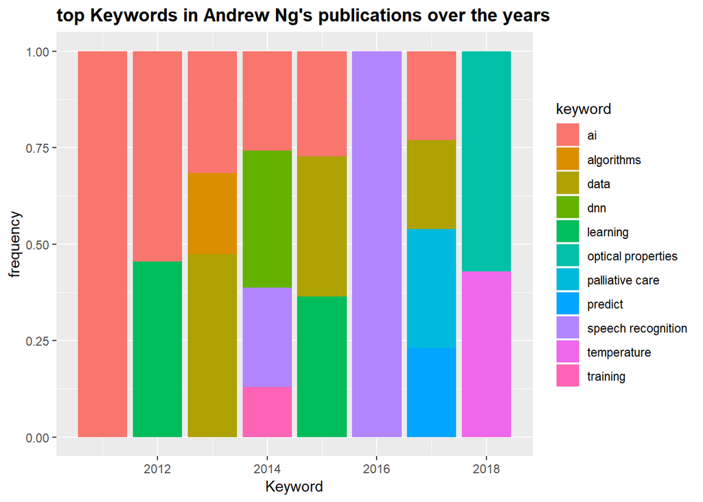

```r
dplt <- ggplot(data=head(aNkw, 20), aes(x = year, y=frequency, fill = keyword)) +
  geom_bar(position="fill", stat = "identity") +
  ggtitle("top Keywords in Andrew Ng's publications over the years") +
 xlab("Keyword")+
  theme(plot.title = element_text(lineheight = .8, face = "bold"))
 dplt + theme(legend.position="right")
```

```r
topKeyW <-as.data.frame(table(abT))
names(topKeyW)<-c("keyword","frequency")
```

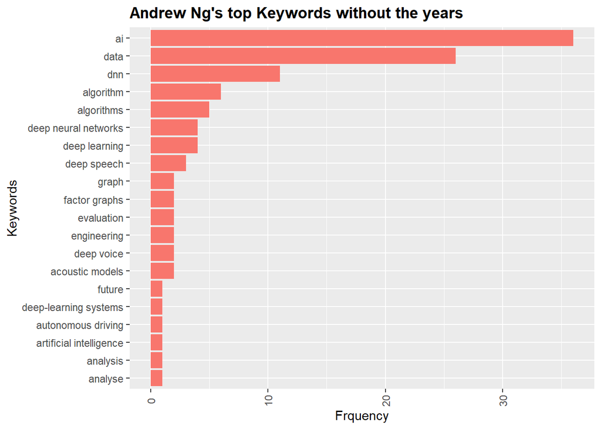

```r
dplt <- ggplot(data=head(topKeyW, 20), aes(x = reorder(keyword, frequency), y=frequency, fill = "steelblue")) +
  geom_bar(stat = "identity") +
 xlab("Keywords")+
  ylab("Frquency")+
  ggtitle("Andrew Ng's top Keywords without the years") +
  theme(plot.title = element_text(lineheight = .8, face = "bold")) +
  theme(axis.text.x = element_text(angle = 90, vjust = .5, size = 9))+ coord_flip()
 dplt + theme(legend.position="none")
```

2. Kira Radinsky